# Preprocessing

Davide la Manna

2023-03-13

## uploading .wav data

To begin with, we will upload a random .wav file representing a “yes”.

```r
file_list <- list.files("yes")
random_file <- sample(file_list, 1)
audio <- readWave(file.path("yes",random_file))
```

let’s try to display and reproduce the following file

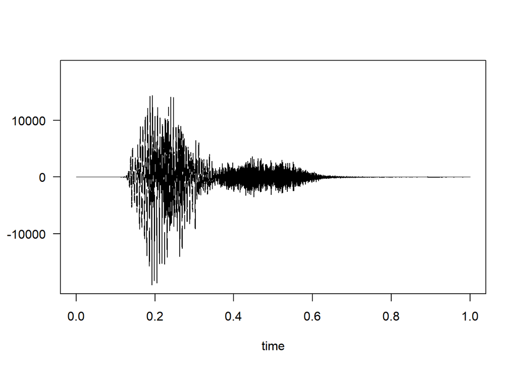

```r
plot(audio)
```

```r
#play(audio)
```

## investigate the class “yes”

Let us now go on to calculate mean and correlation of the MFCC of the word “yes” we utilize the function `compute_mfccs`, it will be uploaded on github

```r
ncep=13 #number of cepstral coefficients required
dir="yes"
setwd("C:/Users/david/OneDrive/Desktop/semester project/git/SemesterProject/speech_commands_v0.02.tar/speech_commands_v0.02")

mfccs<-compute_mfccs(dir,ncep)
```

We now save the array with preprocessed data

```r
 #save(mfccs, file = "yesP.RData")
```

In order to investigate the data, we decide to calculate the mean and correlation of our data and plot the values

```r
mean <- apply(mfccs, c(1,2), mean)
```

this command calculates the average along the third dimension returning us a matrix of size `ncep`*`time` that we plot

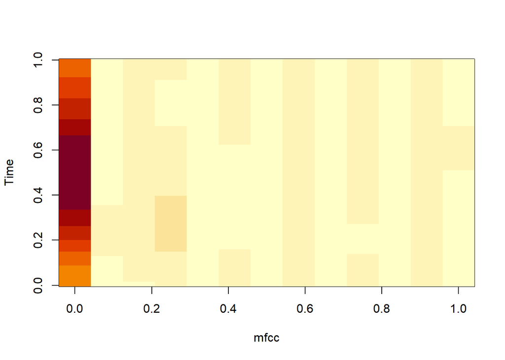

```r
image(t(mean),xlab = "mfcc", ylab = "Time")
```

for the correlation we decide to transform the array into a matrix of dimension `ncep` $\times$ `time` $\times$ `nfile` and calculate the correlation, obtaining a but matrix of dimension `ncep`*`time` $\times$`ncep`*`time` which we plot

```r
vectorized = matrix(mfccs, ncol = ncep*98, byrow = TRUE)
corr=cor(vectorized)
```

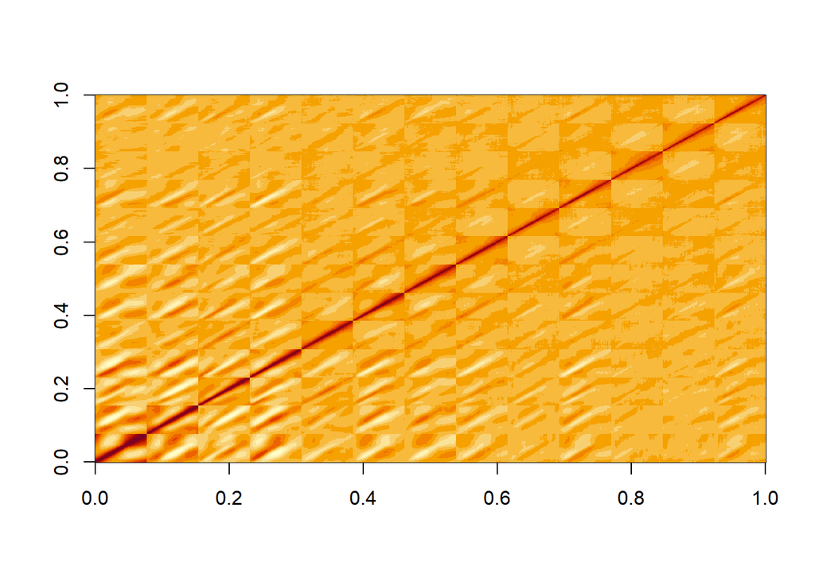

```r
image(corr)
```

As we can see, the covariance matrix in this case will be the vectorization of a tensor of size (13,98,13,98), thus a matrix of size 1274 × 1274, we can see how this matrix consists of 13 x 13 blocks of square matrices of size 98. For example, the matrix on the lower left is the sample covariance matrix for the first cepstral coefficient across the 98 time points.

## Preprocess all the data

We act the same way with all the other classes. For memory reasons we decide not to save all labeled data in one tensor but save the preprocessed data separately and add labels when the classification process starts.

to this end we need only update the previous code with a for loop to perform the operation on all folders

```r
#list_dirs=list.dirs()
#list_dirs<-list_dirs[-1] #omit the empty dir
#for (dir in list_dirs) {
#  mfccs<-compute_mfccs(dir,ncep)
#string <- paste0(dir,"P.RData")
#new_str <- sub("./", "", string)
#save(mfccs, file = new_str)
#}
```

The output of this file will be provided on github

## Conclusion

For the preprocessing of the data, we noticed that some audio files had lengths other than 1 second, and for some, the melfcc function was causing null columns to appear in the spectral decomposition. It was decided not to include these files; fortunately, these represented a minority of the total data and this process was not a problem. We were able to observe graphically that the mean and covariance matrices found are very similar to those found in the work of HOFF et al. so we are very satisfied with our analysis.